# Patrick Crypto Analysis

## Initial Preparation

```python
import warnings
warnings.filterwarnings(action='ignore', category=FutureWarning)
import numpy as np
import pandas as pd
import matplotlib.pyplot as plt
from matplotlib import pyplot
import pandas_datareader as web
from datetime import datetime
from dateutil.relativedelta import relativedelta
import seaborn as sns
import statistics as stat
```

```python
s = datetime(2017, 10, 1)
e = datetime(2020, 8, 1)

delta = 12 * (s.year - e.year) + (s.month - e.month)
delta = delta*-1
```

```python
def variance(data):
    # Number of observations
    n = len(data)
    # Mean of the data
    mean = sum(data) / n
    # Square deviations
    deviations = [(x - mean) ** 2 for x in data]
    # Variance
    variance = sum(deviations) / n
    return variance
```

```python
def data(names):

    #yahoo download
    data = web.DataReader(names, 'yahoo', start=s, end=e)['Adj Close']

    for name in names:
        data['%'+name] = data[name].pct_change()
        data['v'+name] = data[name]
        #data['v2'+name] = data[name]
    data = data.drop(data.index[0])
    print(data)
    data2 = pd.DataFrame(columns = data.columns)

    for i in range(delta):
        for name in names:
            data2.loc[i,name] = data.loc[s+ relativedelta(months=i),name]
            data2.loc[i,'%'+name] = data.loc[s+ relativedelta(months=i),'%'+name]

            #data2.loc[i,'v'+name] = variance(list(data.loc[s+ relativedelta(months=i-1):s+ relativedelta(months=i+1),name]))
            data2.loc[i,'v'+name] = stat.variance(list(data.loc[s+ relativedelta(months=i):s+ relativedelta(months=i+1),'%'+name]))

    data2['date'] = [(s+relativedelta(months=i)).date() for i in range(delta)]

    for name in names:
        data2['n '+name] = np.nan

    data2['total'] = np.nan
    data2['check'] = np.nan

    #data2.drop(0,inplace = True)
    data2 = data2.reset_index(drop = True)

    return data,data2
```

```python
# Heatmap
def heatmap(data,names):
    fig, ax = plt.subplots(figsize=(20,20))
    corr = data[names].corr(method='pearson')
    mask = np.zeros_like(corr)
    mask[np.triu_indices_from(mask)] = True

    with sns.plotting_context("notebook",font_scale=1.3):
        plot =sns.heatmap(corr,fmt = '.2f',annot=True,ax=ax,mask=mask,vmin=-1, vmax=1).set_title('Key Correlations between cryptocurrencies:')
        plt.show()
        plt.clf()
```

# Small Portfolio

```python
#loading data
names = ['BTC-USD', 'ETH-USD', 'XMR-USD', 'ETC-USD']
namesr = ['%'+i for i in names]
df1,df12 = data(names)
```

```
Symbols          BTC-USD     ETH-USD    XMR-USD    ETC-USD  %BTC-USD  \
Date
2017-09-30   4403.740234  302.337006  93.222000  12.741700  0.014988
2017-10-01   4409.319824  297.475006  91.544197  12.437000  0.001267
2017-10-02   4317.479980  292.463013  92.961197  12.406200 -0.020829
2017-10-03   4229.359863  292.657990  90.407097  11.970300 -0.020410
2017-10-04   4328.410156  295.863007  91.858902  11.948100  0.023420
...                  ...         ...        ...        ...       ...
2020-07-27  10912.823242  316.657257  81.306328   7.227256 -0.007101
2020-07-28  11100.467773  318.190887  79.145859   7.271179  0.017195
2020-07-29  11111.213867  334.586639  81.089920   7.352547  0.000968
2020-07-30  11323.466797  345.554657  84.464775   7.408437  0.019103
2020-07-31  11759.592773  385.199707  89.256760   7.814977  0.038515

Symbols         vBTC-USD  %ETH-USD    vETH-USD  %XMR-USD   vXMR-USD  %ETC-USD  \
Date
2017-09-30   4403.740234  0.002893  302.337006 -0.026462  93.222000 -0.018729
2017-10-01   4409.319824 -0.016081  297.475006 -0.017998  91.544197 -0.023914
2017-10-02   4317.479980 -0.016848  292.463013  0.015479  92.961197 -0.002476
2017-10-03   4229.359863  0.000667  292.657990 -0.027475  90.407097 -0.035136
2017-10-04   4328.410156  0.010951  295.863007  0.016059  91.858902 -0.001855
...                  ...       ...         ...       ...        ...       ...
2020-07-27  10912.823242 -0.015106  316.657257  0.035879  81.306328  0.016459
2020-07-28  11100.467773  0.004843  318.190887 -0.026572  79.145859  0.006077
2020-07-29  11111.213867  0.051528  334.586639  0.024563  81.089920  0.011190
2020-07-30  11323.466797  0.032781  345.554657  0.041619  84.464775  0.007601
2020-07-31  11759.592773  0.114729  385.199707  0.056734  89.256760  0.054875

Symbols      vETC-USD
Date
2017-09-30  12.741700
2017-10-01  12.437000
2017-10-02  12.406200
2017-10-03  11.970300
2017-10-04  11.948100
...               ...
2020-07-27   7.227256
2020-07-28   7.271179
2020-07-29   7.352547
2020-07-30   7.408437
2020-07-31   7.814977

[1036 rows x 12 columns]
```

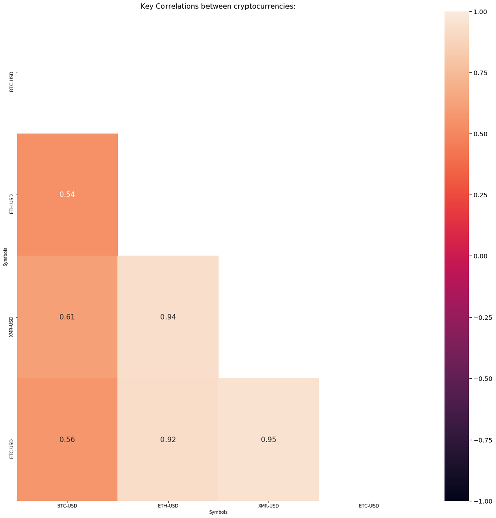

```python
heatmap(df1,names)
```

## Control Method

```python
#Control method modelling
def control(data,names):
    total = 100000
    cache = 0
    cache2 = 0

    for i in range(delta):
        for name in names:

            budget = total/len(names)
            price = data.loc[i,name]
            quantity = budget/price

            data.loc[i,'n '+name] = quantity
            cache += quantity*price

        data.loc[i,'check'] = cache
        cache = 0

        if i != delta-1:
            for name in names:
                newprice = data.loc[i+1,name]
                quantity = data.loc[i,'n '+name]
                cache2 += quantity*newprice


            data.loc[i,'total'] = cache2
            total = cache2
            cache2 = 0
    return data
```

```python
test1 = control(df12,names)
```

## Visualisation

```python
def vis(data,names):
    fig, ax = plt.subplots(figsize=(12,7))
    plot = sns.lineplot(x='date', y="check", data=data,ax=ax).set_title('Invested Sum along time:')
    ax.set(xlabel='Date', ylabel='Total sum')
    plt.show()
    plt.clf()

    data['%check'] = data['check'].pct_change() * 100

    fig, ax = plt.subplots(figsize=(12,7))
    plot = sns.barplot(x='date', y="%check", data=data,ax=ax).set_title('Pct change of Invested sum along time:')
    ax.set(xlabel='Date', ylabel='Pct change of Invested sum (%)')
    fig.autofmt_xdate()
    plt.show()
    plt.clf()

    data['%check2'] = data['%check'].abs()
    print()
    print('Avg pct change =',round(data['%check2'][1:].mean(),4),'%')
    print('volatility = ',round(stat.variance(list(data['%check'])[1:])**0.5,4),'%')
```

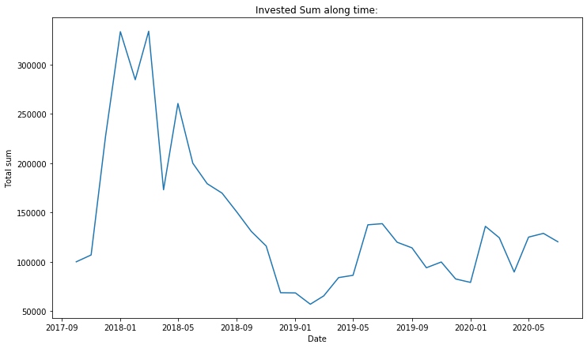

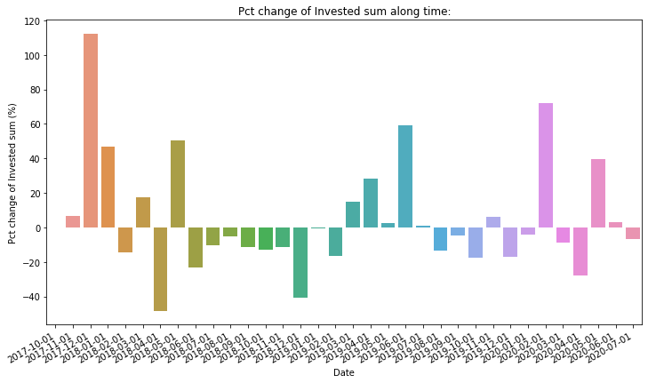

```
Avg pct change = 22.9135 %
volatility =  33.3066 %
```

```python
vis(test1,names)
```

# Larger portfolio

```python
names2 = ['BTC-USD', 'ETH-USD', 'ZEC-USD', 'XMR-USD', 'DOGE-USD', 'ETC-USD', 'XEM-USD', 'DASH-USD', 'DGB-USD', 'LTC-USD', 'XLM-USD', 'XRP-USD', 'BAT-USD', 'MIOTA-USD', 'NEO-USD', 'EOS-USD', 'BNB-USD', 'BCH-USD', 'OMG-USD', 'LINK-USD']
#20 stocks with more than 200 million dollar market cap, which are also older than 2017-10-01
print(len(names2))
namesr2 = ['%'+i for i in names2]
df2,df22 = data(names2)
```

```
20
Symbols          BTC-USD     ETH-USD     ZEC-USD    XMR-USD  DOGE-USD  \
Date
2017-09-30   4403.740234  302.337006  263.944000  93.222000  0.001084
2017-10-01   4409.319824  297.475006  257.600006  91.544197  0.001085
2017-10-02   4317.479980  292.463013  252.942001  92.961197  0.001108
2017-10-03   4229.359863  292.657990  237.910004  90.407097  0.001024
2017-10-04   4328.410156  295.863007  254.815994  91.858902  0.001001
...                  ...         ...         ...        ...       ...
2020-07-27  10912.823242  316.657257   70.970543  81.306328  0.003197
2020-07-28  11100.467773  318.190887   72.432686  79.145859  0.003192
2020-07-29  11111.213867  334.586639   70.890030  81.089920  0.003231
2020-07-30  11323.466797  345.554657   74.604103  84.464775  0.003225
2020-07-31  11759.592773  385.199707   89.748886  89.256760  0.003689

Symbols       ETC-USD   XEM-USD    DASH-USD   DGB-USD    LTC-USD  ...  \
Date                                                              ...
2017-09-30  12.741700  0.246180  315.802002  0.017995  54.543301  ...
2017-10-01  12.437000  0.231441  308.684998  0.016084  53.375999  ...
2017-10-02  12.406200  0.222740  296.234985  0.013948  52.349602  ...
2017-10-03  11.970300  0.218456  305.457001  0.013521  51.399502  ...
2017-10-04  11.948100  0.211072  305.398987  0.013397  51.669498  ...
...               ...       ...         ...       ...        ...  ...
2020-07-27   7.227256  0.051013   79.825203  0.023765  55.575207  ...
2020-07-28   7.271179  0.051518   81.744080  0.023381  55.172005  ...
2020-07-29   7.352547  0.051857   81.382927  0.025296  56.643112  ...
2020-07-30   7.408437  0.052504   82.548203  0.024341  57.998138  ...
2020-07-31   7.814977  0.055827   92.661369  0.026965  61.293224  ...

Symbols     %EOS-USD  vEOS-USD  %BNB-USD   vBNB-USD  %BCH-USD    vBCH-USD  \
Date
2017-09-30 -0.019192  0.707760  0.189275   1.526530 -0.040391  415.152008
2017-10-01 -0.074583  0.654973  0.287017   1.964670  0.014534  421.186005
2017-10-02 -0.036250  0.631230 -0.073279   1.820700 -0.040384  404.177002
2017-10-03 -0.047037  0.601539 -0.120404   1.601480 -0.113144  358.446991
2017-10-04  0.007677  0.606157  0.048087   1.678490 -0.007524  355.750000
...              ...       ...       ...        ...       ...         ...
2020-07-27  0.053736  2.993424  0.028196  20.173548  0.078991  288.552094
2020-07-28  0.010831  3.025847 -0.013778  19.895590 -0.000617  288.374146
2020-07-29  0.008367  3.051163  0.005888  20.012735  0.013247  292.194183
2020-07-30  0.013292  3.091720  0.032750  20.668146  0.028441  300.504517
2020-07-31  0.064873  3.292289  0.041721  21.530432  0.058209  317.996460

Symbols     %OMG-USD  vOMG-USD  %LINK-USD  vLINK-USD
Date
2017-09-30 -0.030193  9.817840  -0.032606   0.436647
2017-10-01 -0.063113  9.198210  -0.182940   0.356767
2017-10-02  0.004932  9.243580  -0.031483   0.345535
2017-10-03 -0.063030  8.660960   0.149988   0.397361
2017-10-04  0.016375  8.802780   0.023095   0.406538
...              ...       ...        ...        ...
2020-07-27  0.016686  1.608426   0.018022   7.223461
2020-07-28  0.007725  1.620851  -0.014865   7.116083
2020-07-29 -0.010808  1.603334   0.042286   7.416992
2020-07-30  0.025131  1.643628   0.047987   7.772913
2020-07-31  0.044720  1.717130   0.068384   8.304459

[1036 rows x 60 columns]
```

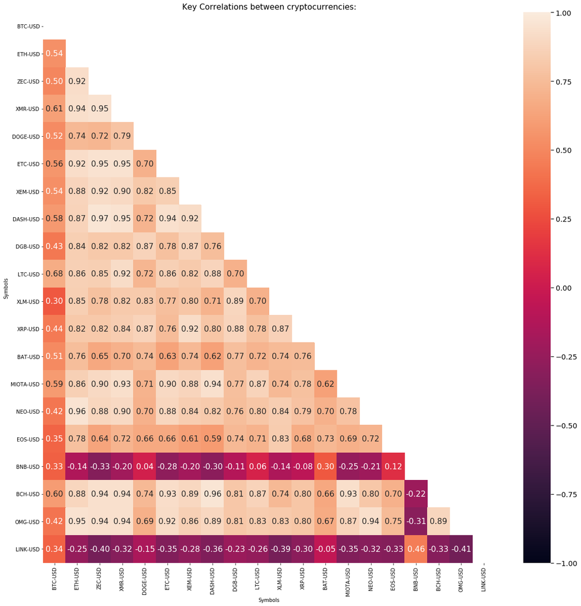

```python
heatmap(df2,names2)
```

## Control Method

```python
test2 = control(df22,names2)
```

## Visualisation

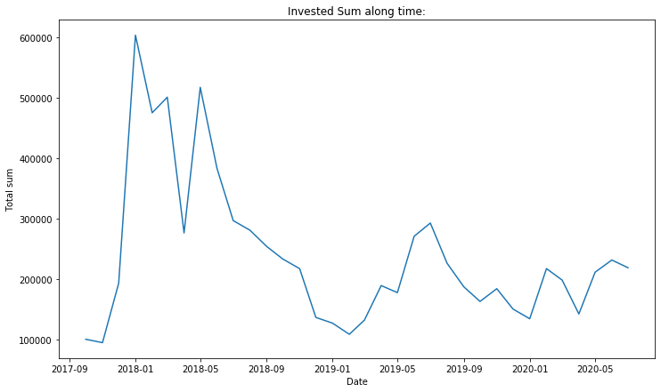

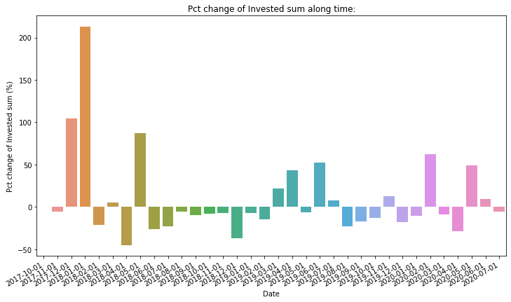

```
Avg pct change = 30.5783 %
volatility =  50.0592 %
```

```python
vis(test2,names2)
```

# Method 2

```python
# Modelling method for variance
def variance(data,names):

    total = 100000
    cache = 0
    cache2 = 0

    weights = pd.DataFrame(index = data.index, columns = names)

    for i in range(delta):
        variances = [1/(data.loc[i,'v'+name]) for name in names]
        for name in names:

            vname = 1/(data.loc[i,'v'+name])

            weight = vname/sum(variances)

            weights.loc[i,name] = weight

            budget = total*weight

            price = data.loc[i,name]

            quantity = budget/price

            data.loc[i,'n '+name] = quantity
            cache += quantity*price

        data.loc[i,'check'] = cache
        cache = 0

        if i != delta-1:
            for name in names:
                newprice = data.loc[i+1,name]
                quantity = data.loc[i,'n '+name]
                cache2 += quantity*newprice


            data.loc[i,'total'] = cache2
            total = cache2
            cache2 = 0

    return data,weights
```

## Smaller Portfolio

```python
test12,weights = variance(df12,names)
```

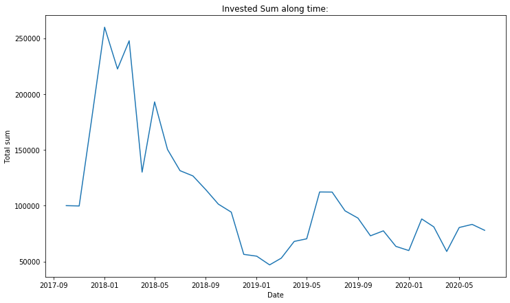

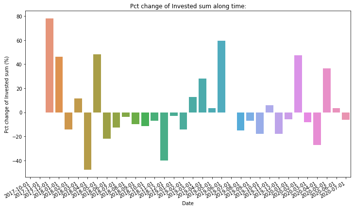

```
Avg pct change = 20.3829 %
volatility =  28.2934 %
```

```python
vis(test12,names)
```

```python
df12[['v'+name for name in names]]#,df12[['%'+name for name in names]]
```

| Symbols | vBTC-USD | vETH-USD | vXMR-USD | vETC-USD |
| --- | --- | --- | --- | --- |
| 0 | 0.00130759 | 0.000877848 | 0.000891313 | 0.00053025 |
| 1 | 0.00206084 | 0.00232119 | 0.0063037 | 0.0150027 |
| 2 | 0.0075072 | 0.00573187 | 0.00971586 | 0.00779168 |
| 3 | 0.00423844 | 0.00604794 | 0.00729363 | 0.0109268 |
| 4 | 0.00492514 | 0.00480784 | 0.009173 | 0.0121823 |
| 5 | 0.00190233 | 0.00186071 | 0.00449077 | 0.00365986 |
| 6 | 0.00197739 | 0.00304519 | 0.00432222 | 0.00394481 |
| 7 | 0.000758738 | 0.00247743 | 0.00167575 | 0.00234289 |
| 8 | 0.00123284 | 0.00217905 | 0.00323207 | 0.00422011 |
| 9 | 0.00106576 | 0.00117401 | 0.00219899 | 0.00137746 |
| 10 | 0.000744655 | 0.00187076 | 0.00301621 | 0.00305304 |
| 11 | 0.000490664 | 0.00391605 | 0.00278646 | 0.0016938 |
| 12 | 0.000204944 | 0.00123645 | 0.000734424 | 0.00103171 |
| 13 | 0.0023608 | 0.00312645 | 0.00361105 | 0.0032655 |
| 14 | 0.00196505 | 0.00486322 | 0.00463507 | 0.00510166 |
| 15 | 0.00064528 | 0.00217143 | 0.00192511 | 0.00175041 |
| 16 | 0.000700878 | 0.00236808 | 0.00129943 | 0.00135966 |
| 17 | 0.00101676 | 0.00120291 | 0.00115604 | 0.00085699 |
| 18 | 0.00130761 | 0.0016412 | 0.00206958 | 0.00442107 |
| 19 | 0.00212595 | 0.00265368 | 0.00297619 | 0.00264165 |
| 20 | 0.00279415 | 0.00211471 | 0.00214256 | 0.00236949 |
| 21 | 0.00262988 | 0.00254632 | 0.00331052 | 0.00198996 |
| 22 | 0.00114814 | 0.00123481 | 0.00192689 | 0.00263146 |
| 23 | 0.000784481 | 0.00174354 | 0.00160308 | 0.0019063 |
| 24 | 0.00144489 | 0.0011623 | 0.00102787 | 0.00123612 |
| 25 | 0.000591911 | 0.000779035 | 0.00132575 | 0.000880024 |
| 26 | 0.000581939 | 0.000867236 | 0.000738602 | 0.00128456 |
| 27 | 0.000769103 | 0.00133069 | 0.00173462 | 0.00554551 |
| 28 | 0.000633642 | 0.0022644 | 0.00213606 | 0.00272186 |
| 29 | 0.00763305 | 0.0102964 | 0.00893146 | 0.00992837 |
| 30 | 0.00124208 | 0.0026632 | 0.00134853 | 0.00234964 |
| 31 | 0.00137702 | 0.00159129 | 0.0013056 | 0.00183572 |
| 32 | 0.000381122 | 0.000532542 | 0.000488399 | 0.000510846 |
| 33 | 0.000534414 | 0.00111803 | 0.000648924 | 0.000930994 |

## Larger Portfolio

```python
test22,weights2 = variance(df22,names2)
```

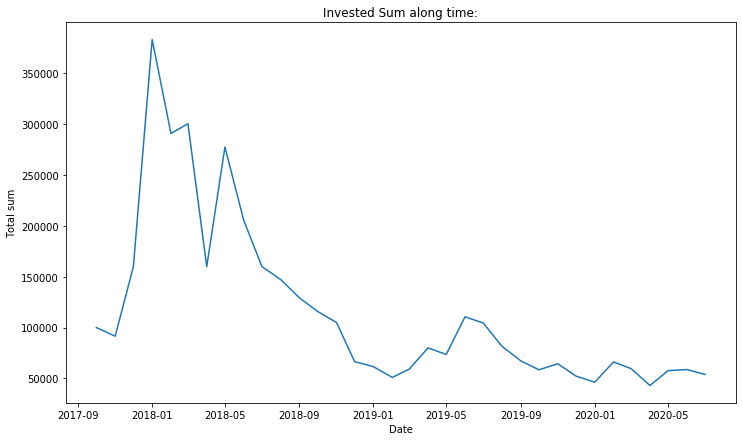

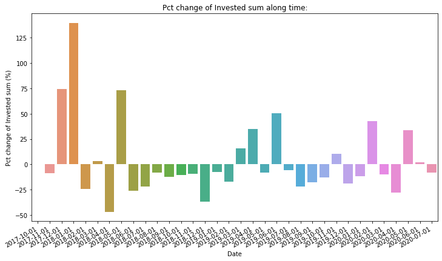

```
Avg pct change = 25.8118 %
volatility =  37.8275 %
```

```python
vis(test22,names2)
```

# Modelling method 3

```python
def cmatrix(data,names):
    data = data[names]

    cdata =  pd.DataFrame(columns = names)
    dummy = pd.Series([1 for i in names])
    dummy = np.matrix([dummy])
    for i in range(delta):
        correlation = data.loc[s+ relativedelta(months=i):s+ relativedelta(months=i+1),:].corr()
        correlation = correlation.to_numpy()

        def inv2(x):
            return 1/x#.abs()
        correlation = pd.DataFrame(correlation).apply(inv2).to_numpy() #23.91,22.7 ;
        #correlation = np.linalg.inv(correlation)# 23.3

        matrix = np.matmul(dummy,correlation)
        matrix = matrix[0].tolist()

        array1 = np.array(matrix[0])
        array1 = np.where(array1<0, 0, array1)
        matrix = array1.tolist()


        cdata.loc[len(cdata)] = matrix
    #print(cdata)
    return cdata
```

```python
def matrix(data,cdata,names,str1):

    total = 100000
    cache = 0
    cache2 = 0

    for i in range(len(data)):
        dummy = [cdata.loc[i,str1+j] for j in names]

        for name in names:

            vname = (cdata.loc[i,str1+name])

            weight = vname/sum(dummy)



            budget = total*weight

            price = data.loc[i,name]

            quantity = budget/price

            data.loc[i,'n'+name] = quantity
            cache += quantity*price

        data.loc[i,'check'] = cache
        cache = 0

        if i != delta-1:
            cache2 = 0
            for name in names:
                newprice = data.loc[i+1,name]
                quantity = data.loc[i,'n'+name]
                cache2 += quantity*newprice

            data.loc[i,'total'] = cache2
            total = cache2
            cache2 = 0
    return data
```

## Small Portfolio

```python
df13 = cmatrix(df1,namesr)
```

```python
test13 = matrix(df12,df13,names,'%')
```

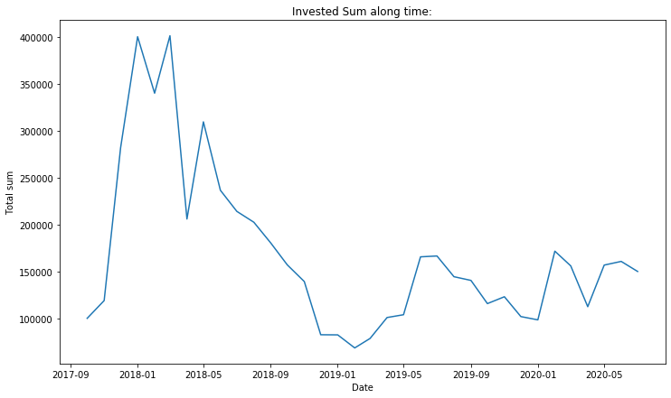

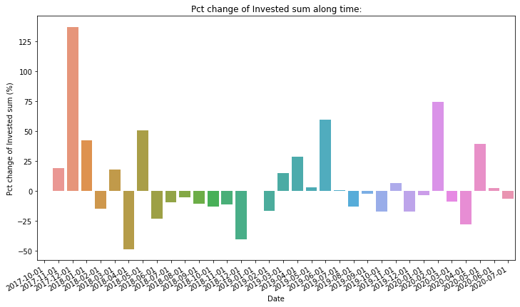

```
Avg pct change = 23.9072 %
volatility =  36.0706 %
```

```python
vis(test13,names)
```

## Large Portfolio

```python
test13['total'][:-1].pct_change().abs().mean()
```

```
0.2406149275046356
```

```python
df23 = cmatrix(df2,namesr2)
```

```python
test23 = matrix(df22,df23,names2,'%')
```

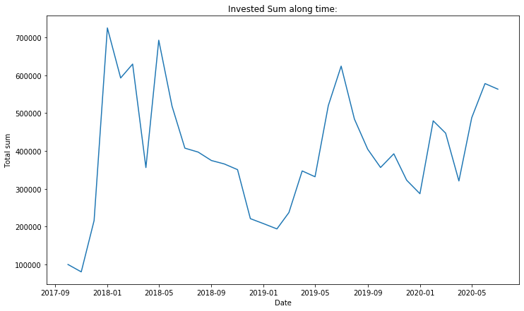

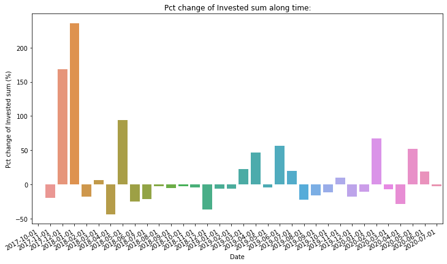

```
Avg pct change = 33.6905 %
volatility =  57.8554 %
```

```python
vis(test23,names2)
```

# Modelling method 4

```python
def cvmatrix(ldata,sdata,names):
    ldata = ldata[names]

    cdata =  pd.DataFrame(columns = names)
    dummy = pd.Series([1 for i in names])
    dummy = np.matrix([dummy])

    for i in range(delta):
        correlation = ldata.loc[s+ relativedelta(months=i):s+ relativedelta(months=i+1),:].corr()
        correlation = correlation.to_numpy()

        def inv2(x):
            return 1/x.abs()
        correlation = pd.DataFrame(correlation).apply(inv2).to_numpy()# NaN,22.36
        #pd.DataFrame(correlation).to_excel('cormatrix.xlsx')
        #correlation = np.linalg.inv(correlation)#30

        variance = pd.DataFrame(columns = names, index = names)
        for name in names:
           variance.loc[name,:] = [sdata['v'+name][i]**.5 for j in range(len(names))]

        variance = variance.to_numpy()
        varianceT = variance.T
        matrixv = np.multiply(variance,varianceT)
        #print(matrixv)
        #pd.DataFrame(matrixv).to_excel('varmatrix.xlsx')

        matrixcv = np.matmul(matrixv,correlation)

        matrix = np.matmul(dummy,matrixcv)
        matrix = matrix[0].tolist()
        array1 = np.array(matrix[0])
        array1 = np.where(array1<0, 0, array1)
        matrix = array1.tolist()

        cdata.loc[len(cdata)] = matrix
    #print(cdata)

    return cdata
```

## Smaller Portfolio

```python
df14 = cvmatrix(df1,df12,names)
```

```python
test14 = matrix(df12,df14,names,'')
```

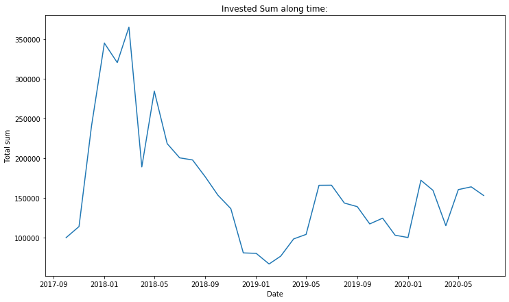

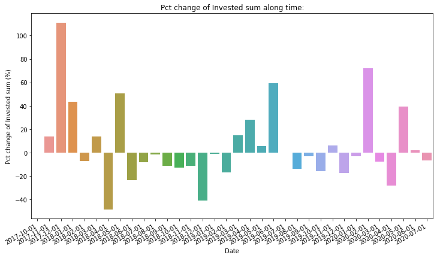

```
Avg pct change = 22.3124 %
volatility =  32.7888 %
```

```python
vis(test14,names)
```

## Larger porfolio

```python
df24 = cvmatrix(df2,df22,names2)
```

```python
test24 = matrix(df22,df24,names2,'')
```

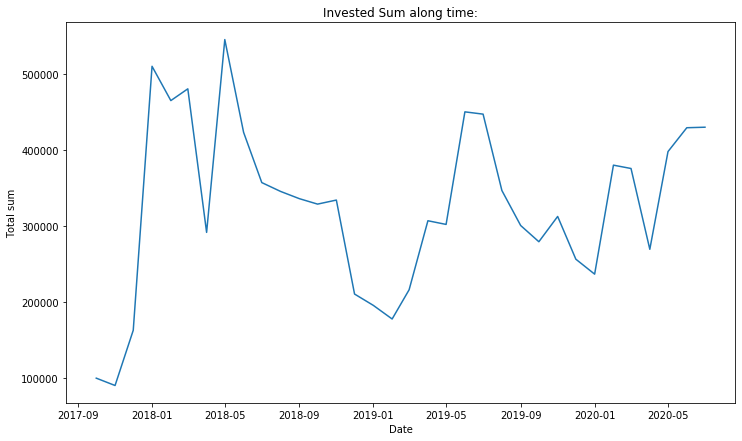

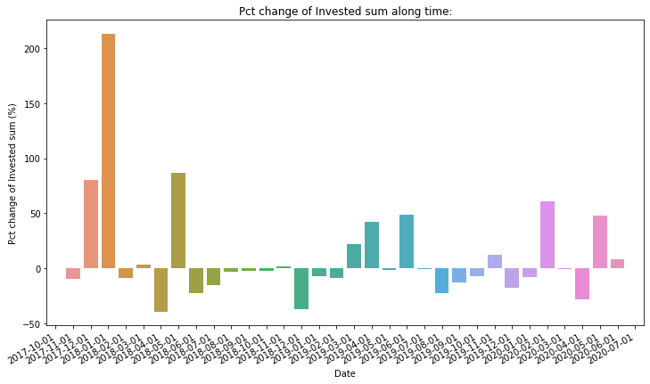

```
Avg pct change = 26.7756 %
volatility =  47.4404 %
```

```python
vis(test24,names2)
```

# Integrating with stocks

## Preparation

```python
s3 = web.DataReader('DIA', 'yahoo', start=s, end=e)['Adj Close']
```

```python
df3 = pd.DataFrame()
df3['DIA'] = s3
```

```python
def metf(etf):#etf = series

    etfindex = list(etf.index)
    j = 0
    metf = []
    dates = []
    for i in range(delta):

        boo1 = True
        while boo1:

            if s+ relativedelta(months=i,days = j) in etfindex:

                metf.append(etf[s+ relativedelta(months=i,days = j)])

                j=0
                boo1 = False
                dates.append(s+ relativedelta(months=i,days = j))
            else:
                #print(s+ relativedelta(months=i,days = j))
                j += 1
        #print(i)

    return metf,dates
```

```python
s3,dates = metf(s3)
len(s3),delta
```

```
(34, 34)
```

## Modelling

```python
def etfmatrix(crypto,weight):

    wDIA = []

    for i in range(delta):

        sum1 = sum(crypto.loc[i,:])

        wDIA.append((sum1/(1-weight))-sum1)

    crypto2 = crypto.copy()
    crypto2['DIA'] = wDIA

    return crypto2
```

```python
names31 = names.copy()
names31.append('DIA')
```

```python
weights
```

|  | BTC-USD | ETH-USD | XMR-USD | ETC-USD |
| --- | --- | --- | --- | --- |
| 0 | 0.155701 | 0.231923 | 0.228419 | 0.383957 |
| 1 | 0.425147 | 0.377462 | 0.138991 | 0.0584001 |
| 2 | 0.247164 | 0.323718 | 0.190978 | 0.23814 |
| 3 | 0.374558 | 0.262493 | 0.217661 | 0.145289 |
| 4 | 0.3372 | 0.345427 | 0.181048 | 0.136325 |
| 5 | 0.337182 | 0.344724 | 0.142833 | 0.175261 |
| 6 | 0.38342 | 0.248973 | 0.175412 | 0.192195 |
| 7 | 0.480104 | 0.147037 | 0.217379 | 0.15548 |
| 8 | 0.446559 | 0.25265 | 0.170336 | 0.130456 |
| 9 | 0.31584 | 0.286718 | 0.153074 | 0.244368 |
| 10 | 0.529426 | 0.210737 | 0.130707 | 0.12913 |
| 11 | 0.628509 | 0.0787495 | 0.110673 | 0.182068 |
| 12 | 0.608475 | 0.100856 | 0.169798 | 0.120871 |
| 13 | 0.319302 | 0.241107 | 0.208751 | 0.23084 |
| 14 | 0.451836 | 0.18257 | 0.191557 | 0.174037 |
| 15 | 0.499749 | 0.14851 | 0.167511 | 0.18423 |
| 16 | 0.425383 | 0.1259 | 0.22944 | 0.219277 |
| 17 | 0.255677 | 0.21611 | 0.224871 | 0.303342 |
| 18 | 0.367062 | 0.292454 | 0.231919 | 0.108565 |
| 19 | 0.301184 | 0.241288 | 0.215141 | 0.242387 |
| 20 | 0.208132 | 0.275004 | 0.271429 | 0.245434 |
| 21 | 0.241034 | 0.248944 | 0.191478 | 0.318545 |
| 22 | 0.337613 | 0.313916 | 0.201167 | 0.147304 |
| 23 | 0.425385 | 0.191396 | 0.208165 | 0.175054 |
| 24 | 0.207566 | 0.258032 | 0.291778 | 0.242623 |
| 25 | 0.347357 | 0.263922 | 0.155086 | 0.233635 |
| 26 | 0.343413 | 0.23044 | 0.270573 | 0.155575 |
| 27 | 0.462953 | 0.267574 | 0.205266 | 0.0642066 |
| 28 | 0.552711 | 0.154664 | 0.163956 | 0.128669 |
| 29 | 0.297197 | 0.220322 | 0.253992 | 0.228489 |
| 30 | 0.342927 | 0.159936 | 0.315856 | 0.18128 |
| 31 | 0.272467 | 0.235778 | 0.287371 | 0.204383 |
| 32 | 0.308444 | 0.220743 | 0.240694 | 0.230118 |
| 33 | 0.347759 | 0.166227 | 0.286392 | 0.199622 |

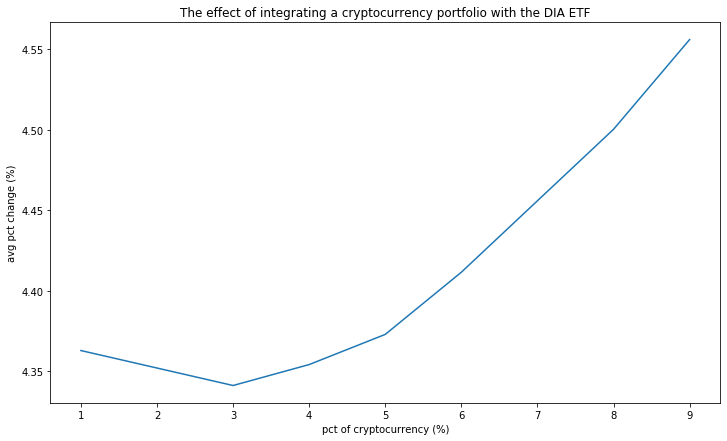

```python
pctchange = []
weights1 = []
for k in range(1,10):

    df31 = pd.DataFrame(etfmatrix(weights,1-k/100))#weights
    #df31 = df31.rename(columns={subset[i]:names[i] for i in range(len(names))})
    #print(df31)
    df15 = df12.copy()
    df15['DIA'] = s3
    df15['nDIA'] = [np.nan for i in range(delta)]

    test31 = matrix(df15,df31,names31,'')

    test31['%total'] = test31['total'].pct_change().abs() * 100

    #pctchange.append(stat.variance(list(test31['%total'])[1:])**0.5)
    pctchange.append(test31['%total'][1:].mean())
    weights1.append(k/100)
fig, ax = plt.subplots(figsize = (12,7))
plot = sns.lineplot(x= [k/1 for k in range(1,10)],y = pctchange,ax= ax).set_title('The effect of integrating a cryptocurrency portfolio with the DIA ETF')#[1-k/10 for k in range(1,11)]
ax.set_xlabel('pct of cryptocurrency (%)')
ax.set_ylabel('avg pct change (%)')
```

```python
weights1
```

```
[0.01, 0.02, 0.03, 0.04, 0.05, 0.06, 0.07, 0.08, 0.09]
```

### Variables

names - small portfolio; name list

df1 - small porfolio; adj close and pct change squared

df12 - small portfolio; monthly; adj close price (first of month) and pct change squared (previous month mean)

df13 - small portfolio; monthly; inverse correlation vector (previous month); cmatrix

df14 - small portfolio; monthly; covariance weight (previous month)

test1 - small portfolio; control

test12 - small portfolio; variance

test13 - small portfolio; correlation

test14 - small portfolio; covariance

_

names2 - large portfolio; name list

df2 - large porfolio; adj close and pct change squared

df22 - large portfolio; monthly; adj close price (first of month) and pct change squared (previous month mean); variance

df23 - large portfolio; monthly; inverse correlation vector (previous month); cmatrix

test2 - large portfolio; control

test22 - large portfolio; variance

test23 - large portfolio; correlation

_

s3 - series of SPDR Dow Jones Industrial Average ETF Trust (DIA) Adj close

### Functions

data(names)

heatmap(data,names)

control(data,names)

vis(data,names)

variance(data,names)

cmatrix(data,names)

matrix(data,cdata,names)

cvmatrix(ldata,sdata,names)

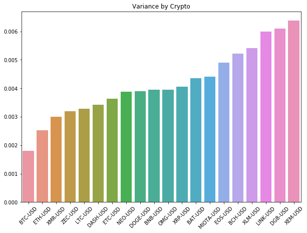

```
['BTC-USD', 'ETH-USD', 'ZEC-USD', 'XMR-USD', 'DOGE-USD', 'ETC-USD', 'XEM-USD', 'DASH-USD', 'DGB-USD', 'LTC-USD', 'XLM-USD', 'XRP-USD', 'BAT-USD', 'MIOTA-USD', 'NEO-USD', 'EOS-USD', 'BNB-USD', 'BCH-USD', 'OMG-USD', 'LINK-USD']
```

```python
dict1 = pd.Series()

for i in names2:

    dict1[i] = df22['v'+i].mean()

dict1 = dict1.sort_values()
fig, ax = plt.subplots(figsize = (10,7))
plot = sns.barplot(x=list(dict1.index),y=dict1,ax=ax).set_title('Variance by Crypto')
plt.setp(ax.get_xticklabels(), rotation=45)
plt.show()
plt.clf()
print(names2)

marketcap = pd.read_html("https://finance.yahoo.com/u/yahoo-finance/watchlists/crypto-top-market-cap/")
```

```
set() ['BTC-USD', 'ETH-USD', 'ZEC-USD', 'XMR-USD', 'DOGE-USD', 'ETC-USD', 'XEM-USD', 'DASH-USD', 'DGB-USD', 'LTC-USD', 'XLM-USD', 'XRP-USD', 'BAT-USD', 'MIOTA-USD', 'NEO-USD', 'EOS-USD', 'BNB-USD', 'BCH-USD', 'OMG-USD', 'LINK-USD']
-0.5164702789574832
```

|  | v | cap |
| --- | --- | --- |
| BTC-USD | 0.001797 | 214150.00 |
| ETH-USD | 0.002524 | 45490.00 |
| ZEC-USD | 0.003195 | 788.45 |
| XMR-USD | 0.003005 | 1670.00 |
| DOGE-USD | 0.003896 | 414.64 |
| ETC-USD | 0.003626 | 754.73 |
| XEM-USD | 0.006382 | 1320.00 |
| DASH-USD | 0.003429 | 839.55 |
| DGB-USD | 0.006093 | 366.41 |
| LTC-USD | 0.003273 | 3790.00 |
| XLM-USD | 0.005405 | 1990.00 |
| XRP-USD | 0.004051 | 12430.00 |
| BAT-USD | 0.004358 | 517.18 |
| MIOTA-USD | 0.004417 | 1010.00 |
| NEO-USD | 0.003885 | 1530.00 |
| EOS-USD | 0.004899 | 2970.00 |
| BNB-USD | 0.003943 | 3330.00 |
| BCH-USD | 0.005225 | 5000.00 |
| OMG-USD | 0.003957 | 718.18 |
| LINK-USD | 0.005995 | 5980.00 |

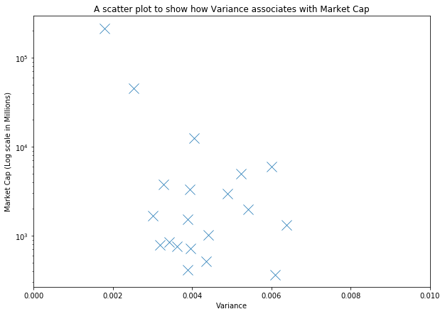

```python
market2 = marketcap[1]
market2 = market2.set_index('Symbol')
market3 = market2['Market Cap']
namescap2  = market3.index
namesv2 = names2
x = set(namescap2)
y = set(namesv2)
namesv3 = y.difference(x)
print(namesv3,namesv2)
#namesv2.remove(list(namesv3)[0])
market4 = pd.DataFrame(columns = ['v','cap'],index = namesv2)
#271
for i in namesv2:
    #print(market3[i])
    if market3[i][-1] == 'B':
       # print()
        market4.loc[i,'cap'] = float(market3[i][:-1])*1000
    else:
        market4.loc[i,'cap'] = float(market3[i][:-1])
    market4.loc[i,'v'] = dict1[i]

market4.loc[:,'v'] = pd.to_numeric(market4['v'])
market4.loc[:,'cap'] = pd.to_numeric(market4['cap'])

print(market4['v'].corr(market4['cap']))
fig, ax = plt.subplots(figsize = (10,7))
ax = sns.scatterplot(x = market4['v'], y = market4['cap'],marker = 'x',s = 200)
ax.set_title('A scatter plot to show how Variance associates with Market Cap')
ax.set_xlim([0,0.01])
ax.set_xlabel('Variance')
ax.set_ylabel('Market Cap (Log scale in Millions)')
ax.set_yscale('log')
market4
```